# Worksheet 13 : Distributions

## Today’s Agenda

- Review of distributions
- Normal Distribution

## Review of Distributions

### Probability Distribution

#### Example

1. What is the probability that it is $70.4$ degrees tomorrow at $1$ pm?

We express continuous distributions with a line instead of of a bar graph:

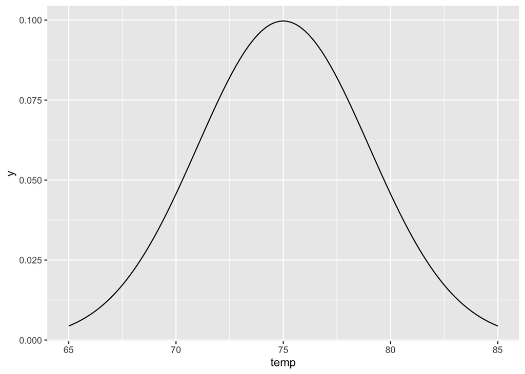

```r
temps <- data.frame(temp = c(65,75,85))
ggplot(temps,aes(x=temp))+ stat_function(fun=dnorm, args = c(75,4))
```

### Population Distribution

#### Example

A manufacturer advertises that their ketchup bottles hold $12.4$ ounces of ketchup. The company standards allow for ketchup bottles to be anywhere between $12.3$ and $12.5$ ounces, but if the bottle falls outside that range it is flagged by quality control. Below is a population distribution for $100,000$ bottles of ketchup produced:

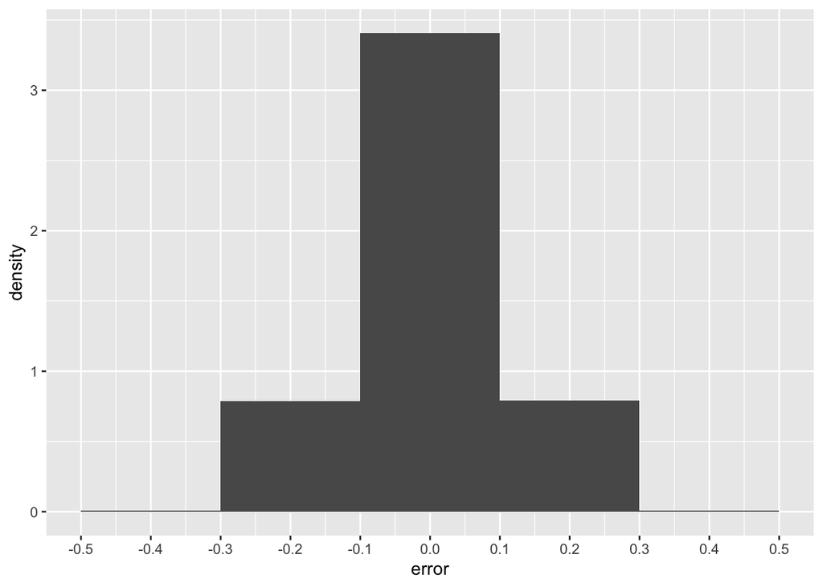

```r
ketchup <- data.frame(error = rnorm(100000,0,.1))
ggplot(ketchup, aes(x=error))+ geom_histogram(binwidth =.2,aes(y=after_stat(density))) + scale_x_continuous(breaks=seq(-.5,.5,.1))
```

2. Approximately what percentage of ketchup bottles are within an acceptable range?

## The Normal Distribution

- One of the most important distributions in statistics is the normal distribution.
- The normal distribution is defined by the function:

$$\frac{1}{\sigma \sqrt{2
\pi}}e^{-\frac{1}{2} \left(\frac{x-\mu}{\sigma} \right)^2}$$

- where $\sigma$ is the standard deviation and $\mu$ is the mean.

### Properties of the normal distribution

- the **standard** normal distribution has mean $0$ and standard deviation $1$:

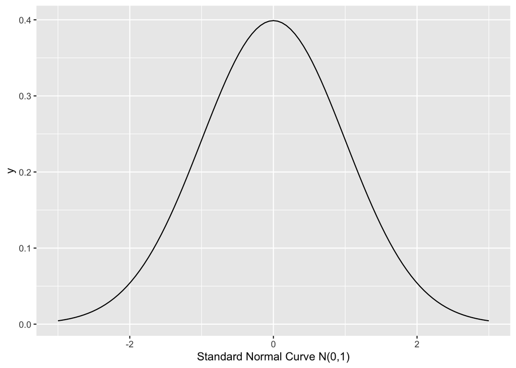

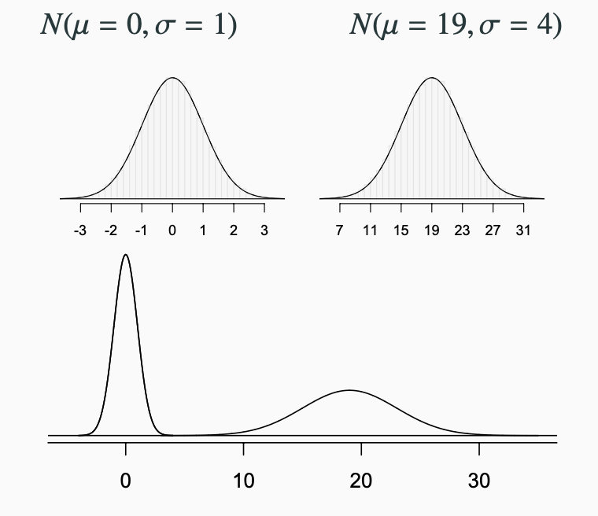

```r
std <- data.frame(axis = seq(-3,3,1))
ggplot(std,aes(x=axis))+ stat_function(fun=dnorm, args = c(0,1)) + labs(x="Standard Normal Curve N(0,1)")
```

3. What percentage of data is below $-1$ on the standard normal curve?

Answer here

4. What percentage of data is greater than $1.5$ on the standard normal curve?

Answer here

5. What percentage of data is between $.5$ and $1.25$ on the standard normal curve?

Answer here